# fredr Package

Sara R. DeMarina

26 September 2023

# Introduction

This code through explores the “fredr” package. This package interacts with an API provided by the Federal Reserve Bank of St. Louis. The main function is fredr(). With the fredr package, you can get time series data from the Federal Reserve of Economic Data (FRED) database.

## Content Overview

Specifically, we’ll explain and demonstrate how to:

1. set up an account, and
2. extract data from FRED.

## Why You Should Care

This topic is valuable because the open source information allows for the general public to use Federal Reserve Bank data to help make informed decisions regarding financial markets.

## Learning Objectives

Specifically, you’ll learn how to create a FRED API key and install fredr.

# FRED in R

## API Key

At [https://fred.stlouisfed.org/docs/api/api_key.html](https://urldefense.com/v3/__https://fred.stlouisfed.org/docs/api/api_key.html__;!!IKRxdwAv5BmarQ!eBFKyTp2y2tUIzYO-gzVZPMEKGyDB9PjMKR2jvGBQU0al_XVqJKC692zKaFqDFdUb2B3OxQuRtCwcYDW_2ZB$):

1. select “Request or view your API Keys”
2. select +Request API Key. Follow the directions to get a key. The key will look somthing like this: abcdefghijklmnopqrstuvwxyz123456

## Setting up R environment

In R studio, select the Tools tab and then install Packages. In the install packages dialog box, input “usethis” in the space for package name. Finish by selecting “Install”.

## Basic Example

```r
# Unemployment Rates

fredr(
  series_id = "UNRATE",
  observation_start = as.Date("2023-01-01"),
  observation_end = as.Date("2023-09-01")
) %>%
  pander()
```

| date | series_id | value | realtime_start | realtime_end |
| --- | --- | --- | --- | --- |
| 2023-01-01 | UNRATE | 3.4 | 2023-09-26 | 2023-09-26 |
| 2023-02-01 | UNRATE | 3.6 | 2023-09-26 | 2023-09-26 |
| 2023-03-01 | UNRATE | 3.5 | 2023-09-26 | 2023-09-26 |
| 2023-04-01 | UNRATE | 3.4 | 2023-09-26 | 2023-09-26 |
| 2023-05-01 | UNRATE | 3.7 | 2023-09-26 | 2023-09-26 |
| 2023-06-01 | UNRATE | 3.6 | 2023-09-26 | 2023-09-26 |
| 2023-07-01 | UNRATE | 3.5 | 2023-09-26 | 2023-09-26 |
| 2023-08-01 | UNRATE | 3.8 | 2023-09-26 | 2023-09-26 |

```r
# Fed Fund Rates

fredr(
  series_id = "FEDFUNDS",
  observation_start = as.Date("2023-01-01"),
  observation_end = as.Date("2023-09-01")
) %>%
  pander()
```

| date | series_id | value | realtime_start | realtime_end |
| --- | --- | --- | --- | --- |
| 2023-01-01 | FEDFUNDS | 4.33 | 2023-09-26 | 2023-09-26 |
| 2023-02-01 | FEDFUNDS | 4.57 | 2023-09-26 | 2023-09-26 |
| 2023-03-01 | FEDFUNDS | 4.65 | 2023-09-26 | 2023-09-26 |
| 2023-04-01 | FEDFUNDS | 4.83 | 2023-09-26 | 2023-09-26 |
| 2023-05-01 | FEDFUNDS | 5.06 | 2023-09-26 | 2023-09-26 |
| 2023-06-01 | FEDFUNDS | 5.08 | 2023-09-26 | 2023-09-26 |
| 2023-07-01 | FEDFUNDS | 5.12 | 2023-09-26 | 2023-09-26 |
| 2023-08-01 | FEDFUNDS | 5.33 | 2023-09-26 | 2023-09-26 |

## Advanced Examples

More specifically, this can be used for graph data. For example, you can graph unemployment rates over a period of time. In the example, you can see how the Pandemic affected unemployment rates.

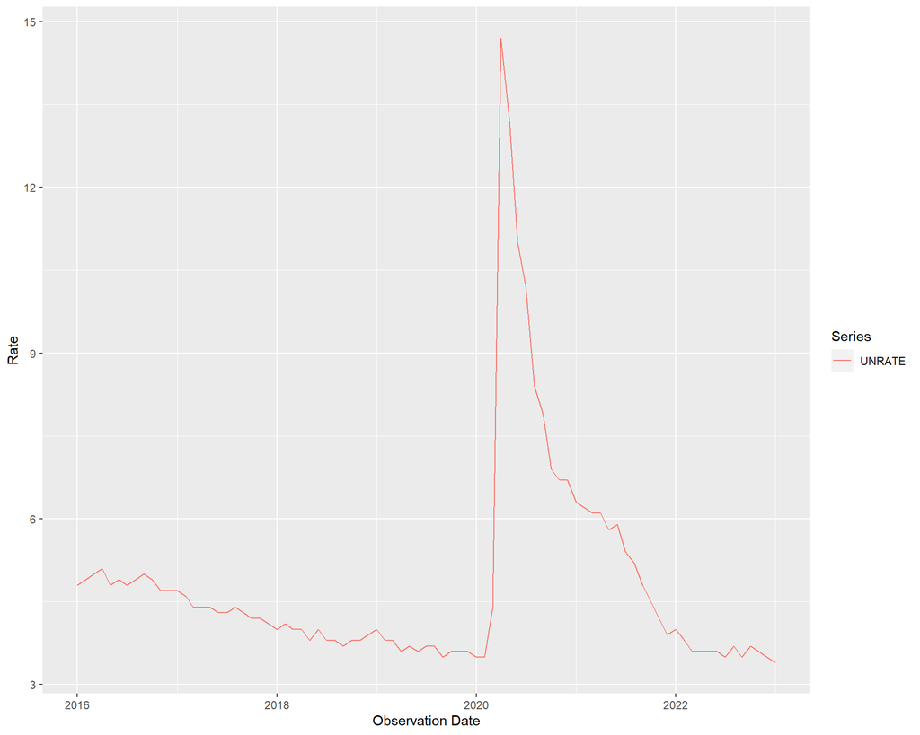

```r
# Graphing Data


  fredr(
  series_id = "UNRATE",
    observation_start = as.Date("2016-01-01"),
    observation_end = as.Date("2023-01-01")
  ) %>%
  ggplot(data = ., mapping = aes(x = date, y = value, color = series_id)) +
    geom_line() +
    labs(x = "Observation Date", y = "Rate", color = "Series")
```

```r
# Search by text


pr1 <- fredr_series_search_text("colorado and sporting")
colnames(pr1)
```

```
##  [1] "id"                        "realtime_start"
##  [3] "realtime_end"              "title"
##  [5] "observation_start"         "observation_end"
##  [7] "frequency"                 "frequency_short"
##  [9] "units"                     "units_short"
## [11] "seasonal_adjustment"       "seasonal_adjustment_short"
## [13] "last_updated"              "popularity"
## [15] "group_popularity"          "notes"
```

```r
pr1 %>%
  select(id, title)
```

| id | title |
| --- | --- |
| MSRSCO451 | Monthly State Retail Sales: Sporting Good, Hobby, Musical Instrument and Book Stores in Colorado |
| COPRFRMSPRTMSMQGSP | Chain-Type Quantity Index for Real GDP: Performing Arts, Spectator Sports, Museums, and Related Activities (NAICS 711-712) in Colorado |
| COPCEPCSRECSRV | Per Capita Personal Consumption Expenditures: Services: Recreation Services for Colorado |
| COPCEPCRECGD | Per Capita Personal Consumption Expenditures: Goods: Durable Goods: Recreational Goods and Vehicles for Colorado |
| COPCESRECSRV | Personal Consumption Expenditures: Services: Recreation Services for Colorado |
| COPCERECGD | Personal Consumption Expenditures: Goods: Durable Goods: Recreational Goods and Vehicles for Colorado |
| COPRFRMSPRTMSMNGSP | Gross Domestic Product: Performing Arts, Spectator Sports, Museums, and Related Activities (NAICS 711-712) in Colorado |
| COPRFRMSPRTMSMRGSP | Real Gross Domestic Product: Performing Arts, Spectator Sports, Museums, and Related Activities (NAICS 711-712) in Colorado |

# Further Resources

- Resource I [Getting started with fredr](https://urldefense.com/v3/__http://sboysel.github.io/fredr/articles/fredr.html__;!!IKRxdwAv5BmarQ!eBFKyTp2y2tUIzYO-gzVZPMEKGyDB9PjMKR2jvGBQU0al_XVqJKC692zKaFqDFdUb2B3OxQuRtCwcbez8ulJ$)
- Resource II [Applying fredr apckage in R: Analyzing FRED domestic car production data for USA](https://urldefense.com/v3/__https://www.youtube.com/watch?v=HB_RYG1S_hI__;!!IKRxdwAv5BmarQ!eBFKyTp2y2tUIzYO-gzVZPMEKGyDB9PjMKR2jvGBQU0al_XVqJKC692zKaFqDFdUb2B3OxQuRtCwcVJODoeU$)
- Resource III World Politics data Lab

# Works Cited

This code through references and cites the following sources:

- Boysel (2023). Source I. [Getting started with fredr](https://urldefense.com/v3/__http://sboysel.github.io/fredr/articles/fredr.html__;!!IKRxdwAv5BmarQ!eBFKyTp2y2tUIzYO-gzVZPMEKGyDB9PjMKR2jvGBQU0al_XVqJKC692zKaFqDFdUb2B3OxQuRtCwcbez8ulJ$)
- Felkl (2020). Source II. [Applying fredr apckage in R: Analyzing FRED domestic car production data for USA](https://urldefense.com/v3/__https://www.youtube.com/watch?v=HB_RYG1S_hI__;!!IKRxdwAv5BmarQ!eBFKyTp2y2tUIzYO-gzVZPMEKGyDB9PjMKR2jvGBQU0al_XVqJKC692zKaFqDFdUb2B3OxQuRtCwcVJODoeU$)
- Yordan (2022). Source III. Accessing and Analyzing Economic Data in R with “fredr”